# Car Sales EDA

## Question 1

Load `car_sales_data.csv` into Python as a pandas DataFrame and describe it:

- How many records are included?
- What years of manufacture are represented?
- Which features are reported?

```python
# Step-1: Loading the dataset
import pandas as pd
car_sales = pd.read_csv('car_sales_data.csv')
```

```python
# Step-2: Display the number of records
num_records = car_sales.shape[0]
print(f'Total number of records: {num_records}')
# Step-3: Display the years of manufacture
years_of_manufacture = car_sales['Year of manufacture'].unique()
print(f'Years of manufacture: {", ".join(map(str, sorted(years_of_manufacture)))}')
# Step-4: Display the features reported
features = car_sales.columns.tolist()
print(f'Features reported: {features}')
```

```
Total number of records: 50000
Years of manufacture: 1984, 1985, 1986, 1987, 1988, 1989, 1990, 1991, 1992, 1993, 1994, 1995, 1996, 1997, 1998, 1999, 2000, 2001, 2002, 2003, 2004, 2005, 2006, 2007, 2008, 2009, 2010, 2011, 2012, 2013, 2014, 2015, 2016, 2017, 2018, 2019, 2020, 2021, 2022
Features reported: ['Manufacturer', 'Model', 'Engine size', 'Fuel type', 'Year of manufacture', 'Mileage', 'Price']
```

## Answer 1:

### Observations:

- **Comprehensive Scope**: The dataset provides a detailed view of car sales data, including key attributes such as price, mileage, and engine size, which are critical for evaluating vehicle value and performance.
- **Temporal Coverage**: The range of years allows for the identification of historical trends, such as shifts in consumer preferences, technological advancements, and market dynamics.
- **Feature Diversity**: The inclusion of diverse features enables multifaceted analysis, from price trends to the impact of mileage and engine size on vehicle valuation.
- **Potential Applications**: This dataset can be used for predictive modeling, market segmentation, and identifying factors influencing car prices.

## Question 2

Explore the distribution of key categorical features:

- Which manufacturers appear most frequently?
- What are the proportions of different fuel types?

```python
# Count the frequency of each manufacturer
manufacturer_counts = car_sales['Manufacturer'].value_counts()
print('Manufacturer frequencies:')
print(manufacturer_counts)

# Calculate the proportions of different fuel types
fuel_type_proportions = car_sales['Fuel type'].value_counts(normalize=True)
print('\nFuel type proportions:')
print(fuel_type_proportions)
```

```
Manufacturer frequencies:
Manufacturer
Ford       14959
VW         14913
Toyota     12554
BMW         4965
Porsche     2609
Name: count, dtype: int64

Fuel type proportions:
Fuel type
Petrol    0.50976
Diesel    0.26536
Hybrid    0.22488
Name: proportion, dtype: float64
```

## Question 3

Identify extremes:

- Which car had the highest sale price?
- Which car had the lowest mileage?
- Which car had the largest engine size?

```python
# Identify extremes
print("Car with the highest sale price:")
display(car_sales.loc[car_sales['Price'].idxmax()])

print("\nCar with the lowest mileage:")
display(car_sales.loc[car_sales['Mileage'].idxmin()])

print("\nCar with the largest engine size:")
display(car_sales.loc[car_sales['Engine size'].idxmax()])
```

```
Car with the highest sale price:
```

```
Manufacturer              BMW
Model                      M5
Engine size               5.0
Fuel type              Petrol
Year of manufacture      2022
Mileage                  4590
Price                  168081
Name: 22786, dtype: object
```

```
Car with the lowest mileage:
```

```
Manufacturer               VW
Model                    Golf
Engine size               1.8
Fuel type              Diesel
Year of manufacture      2022
Mileage                   630
Price                   45601
Name: 30697, dtype: object
```

```
Car with the largest engine size:
```

```
Manufacturer              BMW
Model                      M5
Engine size               5.0
Fuel type              Petrol
Year of manufacture      2016
Mileage                 42059
Price                   91415
Name: 236, dtype: object
```

## Answer-3:

To identify the extremes in the dataset, we use the `idxmax()` and `idxmin()` functions:

### Highest Sale Price:

- The car with the highest price is identified using:

  ```
  car_sales.loc[car_sales['Price'].idxmax()]
  ```

- **Output Analysis**: The row retrieved shows that the car with the highest price is a BMW M5, priced at $168,081. This indicates that the car is a luxury, high-performance vehicle, which justifies its high price. Additionally, its low mileage of 4,590 km suggests it is relatively new.

### Lowest Mileage:

- The car with the lowest mileage is identified using:

  ```
  car_sales.loc[car_sales['Mileage'].idxmin()]
  ```

- **Output Analysis**: The row retrieved shows that the car with the lowest mileage is a VW Golf, with a mileage of 630 km. This suggests that the car is nearly brand new, making it highly appealing to buyers seeking a vehicle with minimal usage.

### Largest Engine Size:

- The car with the largest engine size is identified using:

  ```
  car_sales.loc[car_sales['Engine size'].idxmax()]
  ```

- **Output Analysis**: The row retrieved shows that the car with the largest engine size is a BMW M5, with an engine size of 5.0 liters. This indicates that the car is designed for high performance, which aligns with its luxury branding.

### Conclusion:

- The BMW M5 appears twice in the results (highest price and largest engine size), highlighting its premium status as a high-performance luxury vehicle. The high price and large engine size reinforce its standout position in the dataset.
- The VW Golf, with the lowest mileage of 630 km, represents a nearly new vehicle. This makes it an attractive option for buyers prioritizing minimal usage over other features.
- These extremes provide insights into the diversity of the dataset, showcasing both luxury and practical options available in the market.

## Question 4

Create a numerical summary of numerical features.

```python
# Numerical summary
car_sales.describe()
```

|  | Engine size | Year of manufacture | Mileage | Price |
| --- | --- | --- | --- | --- |
| count | 50000.000000 | 50000.000000 | 50000.000000 | 50000.000000 |
| mean | 1.773058 | 2004.209440 | 112497.320700 | 13828.903160 |
| std | 0.734108 | 9.645965 | 71632.515602 | 16416.681336 |
| min | 1.000000 | 1984.000000 | 630.000000 | 76.000000 |
| 25% | 1.400000 | 1996.000000 | 54352.250000 | 3060.750000 |
| 50% | 1.600000 | 2004.000000 | 100987.500000 | 7971.500000 |
| 75% | 2.000000 | 2012.000000 | 158601.000000 | 19026.500000 |
| max | 5.000000 | 2022.000000 | 453537.000000 | 168081.000000 |

## Answer-4:

The `describe()` method provides a numerical summary of all numerical features, including measures like mean, standard deviation, and percentiles. This summary is essential for understanding the central tendency and spread of the data.

### Observations:

- **Count**: The count for each numerical feature represents the number of non-missing values. If the count is lower than expected, it indicates missing data in the dataset. This could be due to incomplete records or errors during data collection.
- **Mean and Standard Deviation**: These metrics provide insights into the average values and variability of the features. For example, a high standard deviation indicates a wide spread in the data.
- **Min and Max**: These values help identify the range of the data and detect potential outliers.
- **Percentiles**: The 25th, 50th (median), and 75th percentiles give a sense of the data distribution and help identify skewness.

## Question 5

Create visual summaries for price, mileage, and engine size.

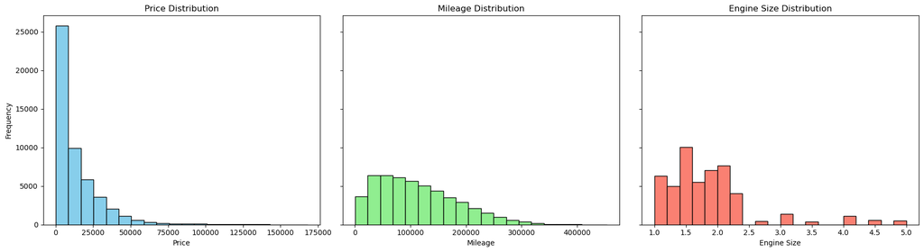

```python
# Visual summaries for price, mileage, and engine size
import matplotlib.pyplot as plt

# Create histograms for numerical features
fig, axes = plt.subplots(1, 3, figsize=(18, 5), sharey=True)

# Price histogram
axes[0].hist(car_sales['Price'], bins=20, color='skyblue', edgecolor='black')
axes[0].set_title('Price Distribution')
axes[0].set_xlabel('Price')
axes[0].set_ylabel('Frequency')

# Mileage histogram
axes[1].hist(car_sales['Mileage'], bins=20, color='lightgreen', edgecolor='black')
axes[1].set_title('Mileage Distribution')
axes[1].set_xlabel('Mileage')

# Engine size histogram
axes[2].hist(car_sales['Engine size'], bins=20, color='salmon', edgecolor='black')
axes[2].set_title('Engine Size Distribution')
axes[2].set_xlabel('Engine Size')

plt.tight_layout()
plt.show()
```

## Answer-5:

Histograms are used to visualize the distribution of numerical features like price, mileage, and engine size. These plots help identify patterns, such as skewness or the presence of outliers, in the data.

### Code Explanation:

- **Matplotlib**: The `matplotlib.pyplot` library is used to create the histograms. It provides flexibility in customizing the plots.
- **Subplots**: A single figure with three subplots is created using `plt.subplots(1, 3, ...)` to display the distributions side by side for easy comparison.
- **Histograms**: The `hist()` function is used to plot the frequency distribution of each feature (price, mileage, engine size).
- **Customization**: Titles, axis labels, and colors are added to enhance readability and visual appeal.

### Observations from the Graphs:

- **Price Distribution**: The histogram for price shows a right-skewed distribution, indicating that most cars are priced in the lower range, with a few high-priced outliers. This is typical in car sales data, where luxury or high-performance vehicles significantly increase the upper range.
- **Mileage Distribution**: The mileage histogram also exhibits a right-skewed pattern, suggesting that most cars have relatively low mileage, with fewer cars having extremely high mileage. This could indicate a preference for newer or less-used vehicles in the dataset.
- **Engine Size Distribution**: The engine size histogram shows a more balanced distribution, with a concentration around smaller engine sizes (e.g., 1.5L to 2.0L). Larger engine sizes are less common, reflecting the market trend toward fuel efficiency and smaller engines in most vehicles.

## Question 6

Produce a scatter plot of price vs mileage, coloured by fuel type.

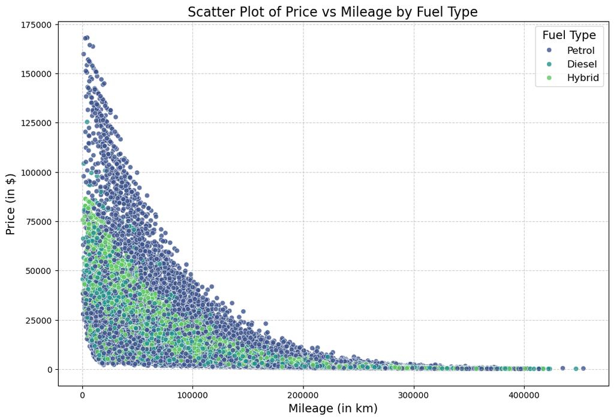

```python
# Scatter plot of price vs mileage, colored by fuel type
import seaborn as sns
import matplotlib.pyplot as plt

# Create the scatter plot
plt.figure(figsize=(12, 8))  # Increased figure size for better clarity
sns.scatterplot(
    data=car_sales,
    x='Mileage',
    y='Price',
    hue='Fuel type',
    palette='viridis',
    alpha=0.8,  # Slightly reduced transparency for better visibility
    edgecolor='w',  # Added white edge color for better distinction of points
    linewidth=0.5  # Thin edge lines for clarity
)

# Add titles and labels
plt.title('Scatter Plot of Price vs Mileage by Fuel Type', fontsize=16)
plt.xlabel('Mileage (in km)', fontsize=14)
plt.ylabel('Price (in $)', fontsize=14)
plt.legend(title='Fuel Type', fontsize=12, title_fontsize=14)

# Display the plot
plt.grid(True, linestyle='--', alpha=0.6)  # Added grid for better readability
plt.show()
```

## Answer-6:

The scatter plot of price vs mileage, colored by fuel type, provides insights into the relationship between these variables and the influence of fuel type on pricing.

### Conclusion:

The scatter plot is a valuable tool for visualizing the interplay between price, mileage, and fuel type. It provides a clear and intuitive way to identify trends, patterns, and anomalies in the data.

## Question 7

Compute price per kilometre.

```python
# Price per kilometre
car_sales['Price_per_km'] = car_sales['Price'] / car_sales['Mileage']
car_sales[['Price', 'Mileage', 'Price_per_km']].head()
```

|  | Price | Mileage | Price_per_km |
| --- | --- | --- | --- |
| 0 | 3074 | 127300 | 0.024148 |
| 1 | 49704 | 57850 | 0.859188 |
| 2 | 24072 | 39190 | 0.614238 |
| 3 | 1705 | 210814 | 0.008088 |
| 4 | 4101 | 127869 | 0.032072 |

# Answer-7:

### Purpose:

The `Price_per_km` metric provides a standardized way to compare the cost of cars relative to their mileage. It helps identify cars that offer better value for money in terms of price per kilometre driven.

### Calculation:

- **Formula**: Price_per_km = Price / Mileage
- This formula divides the price of each car by its mileage to compute the cost per kilometre.

### Insights:

- Cars with **lower `Price_per_km` values** are generally more cost-effective, assuming other factors like condition and age are similar.
- **Outliers** in `Price_per_km` may indicate luxury or high-performance vehicles that command a premium price despite high mileage.

### Considerations:

- Cars with **very low mileage** may have disproportionately high `Price_per_km` values, as the denominator (mileage) is small.
- Cars with **zero mileage** (if any) would result in a division by zero error. These cases should be handled separately.

## Question 8

Plot car price vs year of manufacture, colouring points by manufacturer.

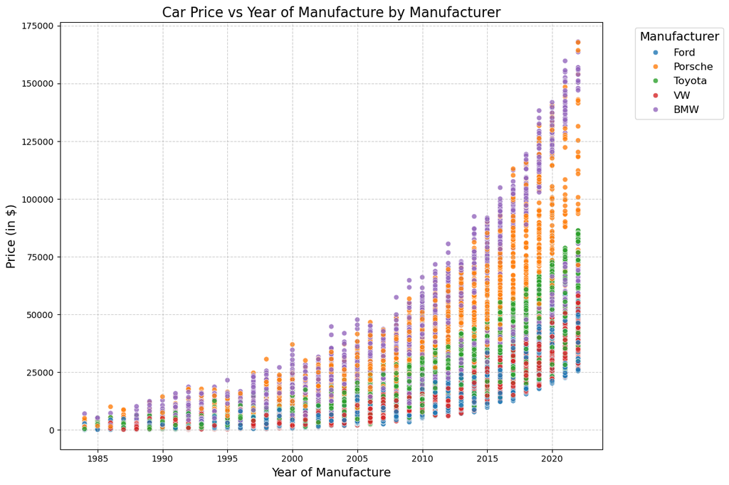

```python
# Price vs year of manufacture
import seaborn as sns
import matplotlib.pyplot as plt

# Create the scatter plot
plt.figure(figsize=(12, 8))
sns.scatterplot(
    data=car_sales,
    x='Year of manufacture',
    y='Price',
    hue='Manufacturer',
    palette='tab10',
    alpha=0.8,
    edgecolor='w',
    linewidth=0.5
)

# Add titles and labels
plt.title('Car Price vs Year of Manufacture by Manufacturer', fontsize=16)
plt.xlabel('Year of Manufacture', fontsize=14)
plt.ylabel('Price (in $)', fontsize=14)
plt.legend(title='Manufacturer', fontsize=12, title_fontsize=14, bbox_to_anchor=(1.05, 1), loc='upper left')

# Display the plot
plt.grid(True, linestyle='--', alpha=0.6)
plt.tight_layout()
plt.show()
```

## Answer-8:

### Code Explanation:

- **Seaborn Library**: The `seaborn` library is used to create the scatter plot, which allows for easy visualization of relationships between variables.
- **Hue Parameter**: The `hue` parameter is used to color the points based on the `Manufacturer` column, enabling differentiation between manufacturers.
- **Alpha and Edgecolor**: Transparency (`alpha=0.8`) and white edge color (`edgecolor='w'`) are applied to improve the clarity of overlapping points.
- **Titles and Labels**: Titles, axis labels, and a legend are added to make the plot informative and visually appealing.

### Conclusion:

The scatter plot effectively visualizes the relationship between car price, year of manufacture, and manufacturer. It provides valuable insights into market trends and the influence of brand reputation on pricing.

## Question 9

Compare Toyota and BMW.

| Manufacturer | Price count | Price mean | Price std | Price min | Price 25% | Price 50% | Price 75% | Price max | Mileage count | Mileage mean | Mileage ... | Mileage 75% | Mileage max | Engine size count | Engine size mean | Engine size std | Engine size min | Engine size 25% | Engine size 50% | Engine size 75% | Engine size max |
| --- | --- | --- | --- | --- | --- | --- | --- | --- | --- | --- | --- | --- | --- | --- | --- | --- | --- | --- | --- | --- | --- |
| BMW | 4965.0 | 24429.459215 | 27901.217685 | 167.0 | 5318.00 | 14384.0 | 33592.00 | 168081.0 | 4965.0 | 112837.733333 | ... | 160042.00 | 453537.0 | 4965.0 | 3.102437 | 1.030934 | 2.0 | 2.2 | 3.0 | 4.0 | 5.0 |
| Toyota | 12554.0 | 14340.362275 | 14706.876784 | 176.0 | 3373.25 | 8802.0 | 20918.25 | 86353.0 | 12554.0 | 111361.126494 | ... | 157628.75 | 416143.0 | 12554.0 | 1.574367 | 0.456752 | 1.0 | 1.2 | 1.4 | 1.8 | 2.4 |

2 rows × 24 columns

```
Average Comparison (Mean values):
```

| Manufacturer | Price | Mileage | Engine size | Year of manufacture |
| --- | --- | --- | --- | --- |
| BMW | 24429.459215 | 112837.733333 | 3.102437 | 2004.048137 |
| Toyota | 14340.362275 | 111361.126494 | 1.574367 | 2004.316951 |

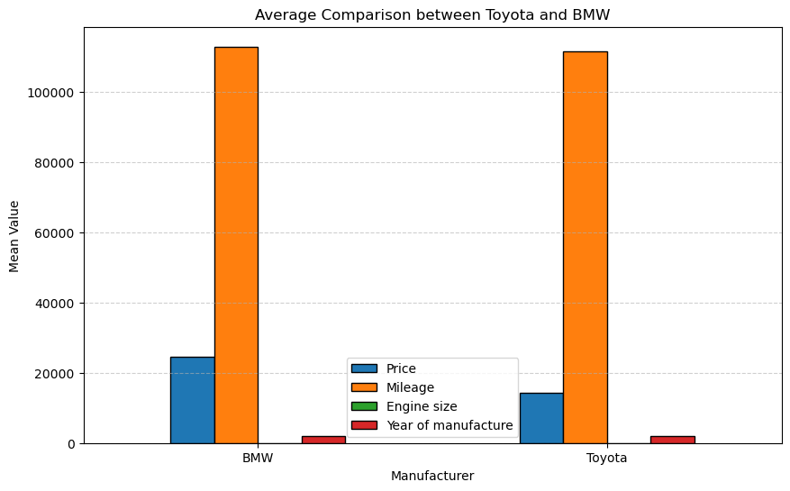

```
 !!  Summary Statistics (All Numeric Columns): !!
```

| Manufacturer | Engine size count | Engine size mean | Engine size std | Engine size min | Engine size 25% | Engine size 50% | Engine size 75% | Engine size max | Year of manufacture count | Year of manufacture mean | ... | Price 75% | Price max | Price_per_km count | Price_per_km mean | Price_per_km std | Price_per_km min | Price_per_km 25% | Price_per_km 50% | Price_per_km 75% | Price_per_km max |
| --- | --- | --- | --- | --- | --- | --- | --- | --- | --- | --- | --- | --- | --- | --- | --- | --- | --- | --- | --- | --- | --- |
| BMW | 4965.0 | 3.102437 | 1.030934 | 2.0 | 2.2 | 3.0 | 4.0 | 5.0 | 4965.0 | 2004.048137 | ... | 33592.00 | 168081.0 | 4965.0 | 0.893884 | 3.203620 | 0.000374 | 0.034623 | 0.146341 | 0.605705 | 111.188587 |
| Toyota | 12554.0 | 1.574367 | 0.456752 | 1.0 | 1.2 | 1.4 | 1.8 | 2.4 | 12554.0 | 2004.316951 | ... | 20918.25 | 86353.0 | 12554.0 | 0.509107 | 1.773487 | 0.000453 | 0.022330 | 0.089657 | 0.394782 | 113.993976 |

2 rows × 40 columns

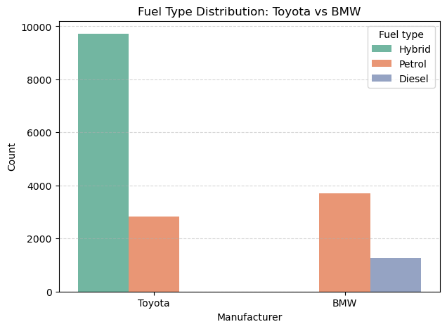

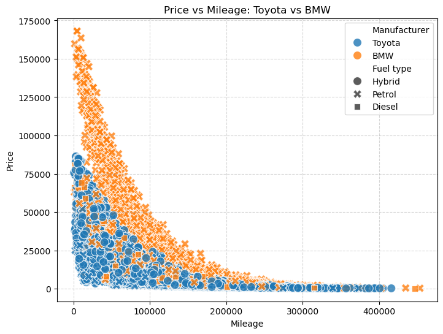

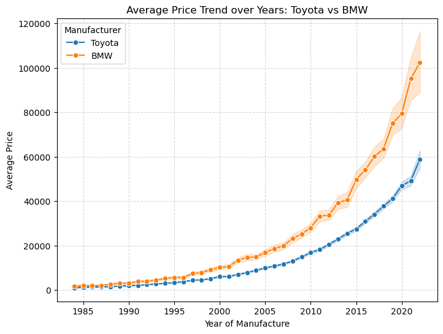

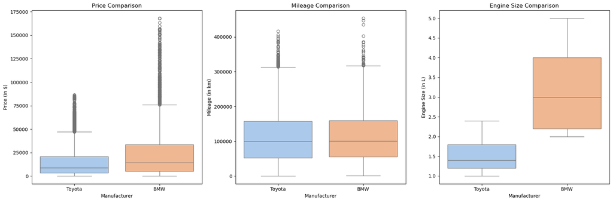

```python
import pandas as pd
import matplotlib.pyplot as plt
import seaborn as sns

# Filter data for Toyota and BMW
toyota_bmw = car_sales[car_sales['Manufacturer'].isin(['Toyota', 'BMW'])]

# Summary statistics for Toyota and BMW
summary_stats = toyota_bmw.groupby('Manufacturer')[['Price', 'Mileage', 'Engine size']].describe()
display(summary_stats)  # Use display() to render the table properly

# Average comparison
avg_comparison = toyota_bmw.groupby('Manufacturer')[['Price', 'Mileage', 'Engine size', 'Year of manufacture']].mean()
print("\nAverage Comparison (Mean values):\n")
display(avg_comparison)

# Bar chart for mean values
avg_comparison.plot(kind='bar', figsize=(10, 6), edgecolor='black')
plt.title("Average Comparison between Toyota and BMW")
plt.ylabel("Mean Value")
plt.xticks(rotation=0)
plt.grid(axis='y', linestyle='--', alpha=0.6)
plt.show()

print(" !!  Summary Statistics (All Numeric Columns): !! \n")
display(toyota_bmw.groupby('Manufacturer').describe())

# Fuel Type Distribution

plt.figure(figsize=(7, 5))
sns.countplot(data=toyota_bmw, x='Manufacturer', hue='Fuel type', palette='Set2')

plt.title("Fuel Type Distribution: Toyota vs BMW")
plt.ylabel("Count")
plt.grid(axis='y', linestyle='--', alpha=0.5)
plt.show()


# Price vs Mileage (Scatter)

plt.figure(figsize=(8, 6))

sns.scatterplot(data=toyota_bmw, x='Mileage', y='Price', hue='Manufacturer', style='Fuel type', s=100, alpha=0.8)
plt.title("Price vs Mileage: Toyota vs BMW")
plt.xlabel("Mileage")
plt.ylabel("Price")
plt.grid(True, linestyle='--', alpha=0.5)
plt.show()

# Yearly Average Price Trend

plt.figure(figsize=(8, 6))
sns.lineplot(data=toyota_bmw, x='Year of manufacture', y='Price', hue='Manufacturer', marker='o')

plt.title("Average Price Trend over Years: Toyota vs BMW")
plt.xlabel("Year of Manufacture")
plt.ylabel("Average Price")

plt.grid(True, linestyle='--', alpha=0.5)
plt.show()

# Visual comparison of Price, Mileage, and Engine Size
fig, axes = plt.subplots(1, 3, figsize=(18, 6))

# Price comparison
sns.boxplot(data=toyota_bmw, x='Manufacturer', y='Price', ax=axes[0], hue='Manufacturer', palette='pastel', dodge=False)
axes[0].set_title('Price Comparison')
axes[0].set_ylabel('Price (in $)')

# Mileage comparison
sns.boxplot(data=toyota_bmw, x='Manufacturer', y='Mileage', ax=axes[1], hue='Manufacturer', palette='pastel', dodge=False)
axes[1].set_title('Mileage Comparison')
axes[1].set_ylabel('Mileage (in km)')

# Engine size comparison
sns.boxplot(data=toyota_bmw, x='Manufacturer', y='Engine size', ax=axes[2], hue='Manufacturer', palette='pastel', dodge=False)
axes[2].set_title('Engine Size Comparison')
axes[2].set_ylabel('Engine Size (in L)')

plt.tight_layout()
plt.show()
```

# Answer-9:

## Code Explanation:

### Filtering Data:

The analysis begins by filtering the dataset to include only Toyota and BMW vehicles using the `isin()` method on the `Manufacturer` column. This creates the `toyota_bmw` DataFrame, ensuring that all subsequent analyses focus exclusively on these two manufacturers.

### Summary Statistics:

The first `groupby('Manufacturer').describe()` call provides detailed summary statistics for key numerical features (`Price`, `Mileage`, and `Engine size`). This includes measures of central tendency (mean, median) and dispersion (standard deviation, interquartile range), offering a quantitative overview of the differences between Toyota and BMW.

### Average Comparison:

The mean values for `Price`, `Mileage`, `Engine size`, and `Year of manufacture` are calculated and visualized using a bar chart. This provides a clear comparison of the average characteristics of Toyota and BMW vehicles.

### Overall Summary Statistics:

A broader `groupby('Manufacturer').describe()` call is used to display descriptive statistics for all numeric columns in the filtered dataset. This ensures that no quantifiable attribute is overlooked in the analysis.

### Fuel Type Distribution:

The `sns.countplot` function is used to visualize the distribution of the categorical variable `Fuel type` for each manufacturer. This highlights the composition of fuel types (e.g., hybrid, petrol, diesel) within Toyota and BMW vehicles.

### Price vs. Mileage:

A scatter plot is generated using `sns.scatterplot` to visualize the relationship between `Mileage` and `Price`. The `hue='Manufacturer'` and `style='Fuel type'` parameters allow for a detailed comparison of how the depreciation curve differs across brands and fuel types.

### Yearly Average Price Trend:

The `sns.lineplot` function is used to plot the average `Price` against `Year of manufacture`. This visualizes the depreciation trend over time for each brand, highlighting the dynamic price gap between newer and older models.

### Visual Comparison:

Three box plots are created using `sns.boxplot` to compare the distributions of `Price`, `Mileage`, and `Engine size` for Toyota and BMW. These plots highlight the median, interquartile range (IQR), and potential outliers for each feature.

## Insights:

### Price and Variability:

- BMW cars consistently command a significantly higher average price and exhibit greater variability in price compared to Toyota.
- This reflects BMW's premium positioning and diverse range of high-spec models.

### Engine Size and Performance:

- BMW vehicles have larger average engine sizes, consistent with their emphasis on high-performance driving experiences.
- Toyota models lean toward smaller, more fuel-efficient engines.

### Fuel Type Strategy:

- Toyota's strength in the hybrid market is evident, while BMW primarily focuses on petrol and diesel vehicles, showcasing different technological priorities.

### Depreciation Curve:

- The scatter plot and line plot reveal that BMW maintains its price premium across age and mileage, though both brands show the expected negative correlation (price decreases as mileage/age increases).

## Conclusion:

The multi-faceted comparison provides a clear, data-driven profile of the two brands' relative strengths in the used car market.